# Introducción al software estadístico R (con Starwars ⚔)

Formación ASEPELT. Universidad de Granada

Autor/a

Gema Fernández-Avilés

**IMPORTANTE**

📕 **Como buen estudiante que eres, sabrás lo importante que es trabajar de forma autónoma y venir a clase con el material leído 😊**.

🦄 Este icono indica **AVANZADO E IMPORTANTE**

# 1 🛠 Toolkit del curso: R, RStudio y Quarto

El objetivo de esta unidad es presentar **R**, **RStudio** y **Quarto**, herramientas imprescindibles, que utilizará a lo largo del curso.

## 1.1 Prerrequisitos

Se asume que has revisado las Unidad 1 “Toolkit del curso: R, RStudio y Quarto” y que tienes instalado y funcionando todo lo propuesto en la Unidad O “Calentando motores”.

## 1.2 Terminología

Ya hemos utilizado algunos términos nuevos, así que vamos a definirlos antes de continuar.

- **R:** Nombre del lenguaje de programación que utilizaremos a lo largo del curso.
- **RStudio:** Entorno de desarrollo integrado para R. En otras palabras, una interfaz conveniente para escribir y ejecutar código R.
- **Quarto:** Sistema de publicación científica y técnica de código abierto basado en Pandoc. Crea y publique artículos, informes, presentaciones, sitios web, blogs y libros de alta calidad en HTML, PDF, MS Word, ePub, etc., incluyendo ecuaciones, citas, referencias cruzadas, paneles de figuras, llamadas, diseño avanzado y mucho más.
- **Proyecto:** Un proyecto es un directorio de trabajo (carpeta) que contiene todo lo necesario para trabajar en un análisis de datos (proyecto) específico. Tipos de proyectos: documentos, presentaciones, paquetes, Webs.
- **Paquete:** Un paquete es una colección de funciones, datos y documentación que extiende las capacidades de **R**. Ejemplo: `tydiverse`, `ggplot2`, `dplyr`.
- **Función:** Una función es un bloque de código que realiza una tarea específica. Las funciones toman argumentos, realizan alguna tarea y devuelven un resultado. Ejemplo: `mean()`, `ggplot()`, `filter()`.
- **Chunk:** Un chunk es un bloque de código **R** que se ejecuta en un documento, Quarto en nuestro caso.

## 1.3 Empezar despacio

A medida que avanza el curso, se anima al estudiante a explorar más allá de lo que dictan las clases. Sin embargo, antes de llegar a esa etapa, se necesita adquirir cierta fluidez básica en **R**. En primer lugar, comprobemos que el proyecto que hemos creado funciona perfectamente. En el debemos trabajar todo el curso.

`File > New Project > New Directory > Quarto Project > Poner nombre y seleccionar directorio`

Estructura de carpetas dentro del proyecto:

- 📂 `data`
- 📂 `img`

**Quarto**

Recuerda que en la **Unidad 1** del curso tienes todo lo necesario para realizar la Tarea 1.

Una guía detallada sobre Quarto en RStudio está disponible en el siguiente enlace: https://quarto.org/docs/get-started/hello/rstudio.html

# 2 🚑 La importancia del contexto

**Tu turno**

## 2.1 Tu turno

Completa las partes del código señaladas por `_____` o `xxxxx` para obtener el resultado deseado y acuérdate de cambiar `eval: false` por `eval: true` cuando lo hayas cumplimentado para que se ejecute correctamente la chunk.

## 2.2 Manos a la obra

**R: nuestro contexto**

Nosotros vamos a contar historias con los datos usando el software estadístico **R** por lo que es necesario conocer algunos paquetes y funciones para poder manipular y representar los datos.

## 2.3 Toma toda la ayuda que te presten: `dplyr :: Cheatsheet`

https://rstudio.github.io/cheatsheets/translations/spanish/data-transformation_es.pdf

- Datos **tidy**: ordenados
- Cada fila es una **observación**
- Cada columna es una **variable**
- **pipes**`x |> f(y)` será `f(x,y)`

## 2.4 El conjunto de datos `starwars`

[figure not shown]

**Fuente: https://datasciencebox.org**

## 2.5 Nuestra filosofía: *learning by doing*

**Paso 1** Cargamos los datos `starwars` contenidos en el paquete `dplyr`.

```r
library("dplyr")
starwars
```

```
# A tibble: 87 × 14
   name     height  mass hair_color skin_color eye_color birth_year sex   gender
   <chr>     <int> <dbl> <chr>      <chr>      <chr>          <dbl> <chr> <chr>
 1 Luke Sk…    172    77 blond      fair       blue            19   male  mascu…
 2 C-3PO       167    75 <NA>       gold       yellow         112   none  mascu…
 3 R2-D2        96    32 <NA>       white, bl… red             33   none  mascu…
 4 Darth V…    202   136 none       white      yellow          41.9 male  mascu…
 5 Leia Or…    150    49 brown      light      brown           19   fema… femin…
 6 Owen La…    178   120 brown, gr… light      blue            52   male  mascu…
 7 Beru Wh…    165    75 brown      light      blue            47   fema… femin…
 8 R5-D4        97    32 <NA>       white, red red             NA   none  mascu…
 9 Biggs D…    183    84 black      light      brown           24   male  mascu…
10 Obi-Wan…    182    77 auburn, w… fair       blue-gray       57   male  mascu…
# ℹ 77 more rows
# ℹ 5 more variables: homeworld <chr>, species <chr>, films <list>,
#   vehicles <list>, starships <list>
```

**Paso 2** ¿Cuántas columnas (variables) tiene?

```r
ncol(starwars)
```

```
[1] 14
```

**Paso 3** ¿Cuántas filas (observaciones) tiene?

```r
nrow(starwars)
```

```
[1] 87
```

**Paso 4** ¿Cuál es la dimensión del dataset?

```r
dim(starwars)
```

```
[1] 87 14
```

**Paso 5** ¿Cómo extraer una **variable** del `data.frame`?

Opción 1: formato tidy

```r
nombre_dataframe |> select(nombre_variable)
```

Opción 2: Con el operador `$`

```r
nombre_dataframe$nombre_variable
```

**Tu turno**

Selecciona la variable `name` del conjunto de datos `starwars`.

```r
# Tu código R aquí
```

**Paso 6** Para asignar “algo” (la variable `name`) a “algo” (el objeto `sw_name`) se utiliza el operador `<-`.

```r
sw_name <- starwars$name
```

**Operador `<-`**

El operador `<-` asigna al “símbolo” que hay a su izquierda el resultado de la expresión que hay a su derecha. El operador `=` funciona “igual” que `<-`.

**Paso 7** ¿Como extraer una observación del conjunto de datos?

```r
nombre_dataframe|>
  filter(nombre_variable == "nombre_observacion")
```

**Tu turno**

Selecciona una observación (el bueno), `Luke Skywalker`, filtrando por el nombre en la variable `name` del conjunto `starwars`

```r
# Tu código R aquí
```

**Paso 8** Exploración del dataset `starwars` de un **vistazo** (con la función `skim()` de la librería `skimr`):

```r
skimr::skim(starwars)
```

Data summary

| Name | starwars |
| --- | --- |
| Number of rows | 87 |
| Number of columns | 14 |
| _______________________ |  |
| Column type frequency: |  |
| character | 8 |
| list | 3 |
| numeric | 3 |
| ________________________ |  |
| Group variables | None |

**Variable type: character**

| skim_variable | n_missing | complete_rate | min | max | empty | n_unique | whitespace |
| --- | --- | --- | --- | --- | --- | --- | --- |
| name | 0 | 1.00 | 3 | 21 | 0 | 87 | 0 |
| hair_color | 5 | 0.94 | 4 | 13 | 0 | 11 | 0 |
| skin_color | 0 | 1.00 | 3 | 19 | 0 | 31 | 0 |
| eye_color | 0 | 1.00 | 3 | 13 | 0 | 15 | 0 |
| sex | 4 | 0.95 | 4 | 14 | 0 | 4 | 0 |
| gender | 4 | 0.95 | 8 | 9 | 0 | 2 | 0 |
| homeworld | 10 | 0.89 | 4 | 14 | 0 | 48 | 0 |
| species | 4 | 0.95 | 3 | 14 | 0 | 37 | 0 |

**Variable type: list**

| skim_variable | n_missing | complete_rate | n_unique | min_length | max_length |
| --- | --- | --- | --- | --- | --- |
| films | 0 | 1 | 24 | 1 | 7 |
| vehicles | 0 | 1 | 11 | 0 | 2 |
| starships | 0 | 1 | 16 | 0 | 5 |

**Variable type: numeric**

| skim_variable | n_missing | complete_rate | mean | sd | p0 | p25 | p50 | p75 | p100 | hist |
| --- | --- | --- | --- | --- | --- | --- | --- | --- | --- | --- |
| height | 6 | 0.93 | 174.60 | 34.77 | 66 | 167.0 | 180 | 191.0 | 264 | ▂▁▇▅▁ |
| mass | 28 | 0.68 | 97.31 | 169.46 | 15 | 55.6 | 79 | 84.5 | 1358 | ▇▁▁▁▁ |
| birth_year | 44 | 0.49 | 87.57 | 154.69 | 8 | 35.0 | 52 | 72.0 | 896 | ▇▁▁▁▁ |

# 3 📊 La elección de un gráfico efectivo. ¿Cómo describirías la relación entre la masa (`mass`) y la altura (`height`) de los personajes de Starwars (`starwars`) mediante una visualización?

**¿Cómo visualizar con la función `ggplot()` del paquete `ggplot2`? Recuerda:**

**Paso 1** Cargar el paquete `ggplot` con la función `library()`.

```r
library(ggplot2)
```

**Paso 2** Utilizar la función `ggplot()` y la estética `aesthetics` 👸.

```r
ggplot(data = nuestro_dataset,
       mapping = aes(x = x-variable,
                     y = y-variable,
                     colour = xxxxx,
                     shape = xxxxx,
                     size = xxxxx,
                     alpha = xxxxx)
       ) +
  geom_xxxx() +
   otras opciones
```

**Paso (iii)** Punto de partida

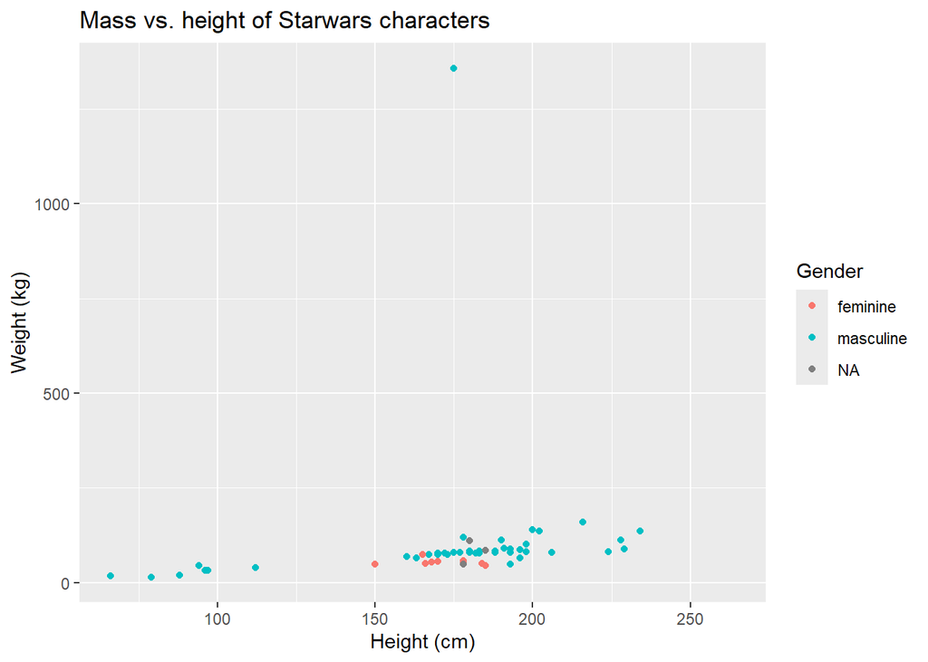

```r
ggplot(data = starwars,
       mapping = aes(x = height,
                     y = mass,
                     colour = gender)) +
  geom_point() +
  labs(title = "Mass vs. height of Starwars characters",
       x = "Height (cm)",
       y = "Weight (kg)",
       colour = "Gender")
```

# 4 😔 El desorden es tu enemigo

Para evitar el desorden, podemos simplificar la visualización eliminando elementos innecesarios y enfocándonos en lo esencial. ¿Son necesarios los `NA` en este caso? ¿El fondo gris aporta información?

**Paso 1** Elimino los datos faltantes, NA (Not Avaliable) con la función `is.na()`, indicando que filtre los que son distintos a NA (con el operador `!`). Guardo el nuevo conjunot de datos en el objeto `starwars_clean`.

```r
starwars_clean <- starwars |>
  filter(!is.na(gender))
```

```r
summary(is.na(starwars_clean))
```

```
    name           height           mass         hair_color
 Mode :logical   Mode :logical   Mode :logical   Mode :logical
 FALSE:83        FALSE:77        FALSE:56        FALSE:78
                 TRUE :6         TRUE :27        TRUE :5
 skin_color      eye_color       birth_year         sex
 Mode :logical   Mode :logical   Mode :logical   Mode :logical
 FALSE:83        FALSE:83        FALSE:43        FALSE:83
                                 TRUE :40
   gender        homeworld        species          films
 Mode :logical   Mode :logical   Mode :logical   Mode :logical
 FALSE:83        FALSE:73        FALSE:83        FALSE:83
                 TRUE :10
  vehicles       starships
 Mode :logical   Mode :logical
 FALSE:83        FALSE:83
```

**Paso 3** Cambio el tema del fondo del gráfico. Prueba algunos y elige el que consideres más apropiado: `theme_bw()`, `theme_minimal()`, `theme_light()`, `theme_dark()`,…

```r
ggplot(data = starwars_clean,
       mapping = aes(x = height,
                     y = mass,
                     colour = gender)) +
  geom_point() +
  labs(title = "Mass vs. Height of Starwars Characters",
       x = "Height (cm)", y = "Weight (kg)",
       colour = "Gender") +
  theme_xxx()
```

# 5 🛑 Centra la atención de tu audiencia

Para centrar la atención, podemos analizar ciertos puntos de interés, como los personajes con alturas y pesos extremos.

**Paso 1** Centro la atención en el personaje *outlier* para ver quién es. Para ello filtro (`filter()`) los valores de la variable `mass > 1000` e indico que ponga una etiqueta con la variable `label = name` .

```r
ggplot(starwars_clean |>
         filter(_____ > ____),
       aes(x = ___,
           y = ___,
           label = ____,
           colour = ____)) +
  geom_point() +
  geom_text(hjust = 1.1, vjust = 1.1, size = 3) +
  labs(title = "Characters with Mass Greater than 1000",
       x = "Height (cm)",
       y = "Weight (kg)",
       colour = "Gender") +
  theme_bw()
```

**Paso 2** Determinamos el conjunto de datos objetivo. En este caso, eliminamos el personaje *outlier*, `Jabba Desilijic Tiure`, del conjunto de datos `starwars_clean` y lo guardamos en el objeto `starwars_clean_sin_outlier`.

```r
starwars_clean_sin_outlier <- starwars_clean |>
      filter(name != "Jabba Desilijic Tiure")
```

**Paso 3** Representamos el diagrama de dispersión del conjunto de datos `starwars_clean_sin_outlier`.

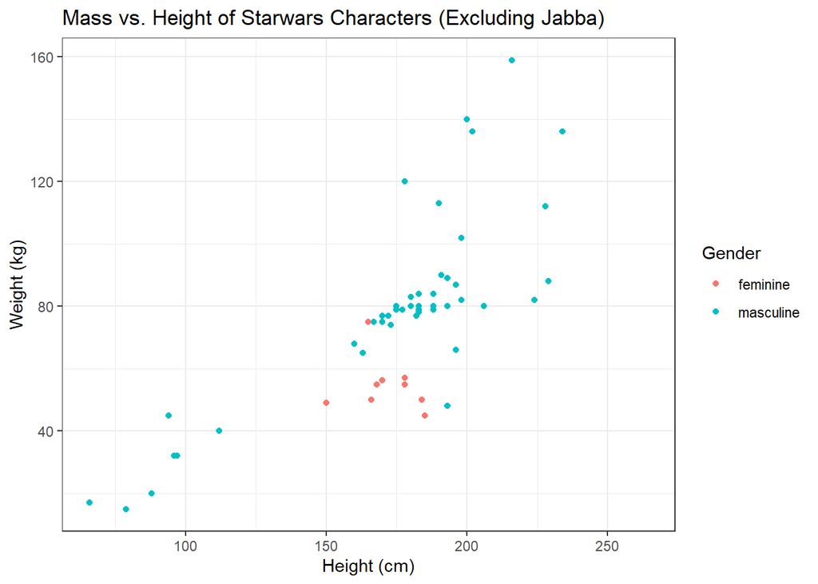

```r
ggplot(starwars_clean_sin_outlier,
       mapping = aes(x = height,
                     y = mass,
                     colour = gender)) +
  geom_point() +
  labs(title = "Mass vs. Height of Starwars Characters (Excluding Jabba)",
       x = "Height (cm)", y = "Weight (kg)",
       colour = "Gender") +
    theme_bw()
```